# week5 case2

```r
library(readxl)
price_high = read_excel(
  "case2.xlsx", sheet = "high", range = "B2:D4",
  col_names = FALSE
)
phdf = data.frame(price_high)
price_low = read_excel(
  "case2.xlsx", sheet = "low", range = "B2:D4",
  col_names = FALSE
)
pldf = data.frame(price_low)
makeVector = function(dat){
  nc = ncol(dat)

  for (i in 1:nc){
    if (i == 1){
      mydata = dat[,1]
    }
    else{
      mydata = c(mydata, dat[,i])
    }
  }

  return (mydata)
}
makeData = function(vec){
  p = length(vec)

  mydata = data.frame(
    PRICE = factor(
      c(
        rep("H", p/2),
        rep("L", p/2)
    )),
    FUNC = factor(
      rep(c(
        rep("FEW", 3),
        rep("SOME", 3),
        rep("MANY", 3)
      ), 2)
    ),
    SALES = vec
  )

  return (mydata)
}
drawPrice = function(mydata){
  curve(
    dnorm(x,
      mean(mydata[mydata$PRICE=="H", "SALES"]),
      var(mydata[mydata$PRICE=="H", "SALES"])
    ),
    xlim=c(
      min(mydata$SALES),
      max(mydata$SALES)
    ),
    col=2, ylab=""
  )

  par(new=T)
  curve(
    dnorm(x,
      mean(mydata[mydata$PRICE=="L", "SALES"]),
      var(mydata[mydata$PRICE=="L", "SALES"])
    ),
    xlim=c(
      min(mydata$SALES),
      max(mydata$SALES)
    ),
    col=3, axes=F, ylab=""
  )

  par(xpd=T)
  legend(
    par()$usr[2], par()$usr[4],
    legend=c("H", "L"),
    pch=20, col=2:3
  )
}
drawFunc = function(mydata){
  curve(
    dnorm(x,
      mean(mydata[mydata$FUNC=="FEW", "SALES"]),
      var(mydata[mydata$FUNC=="FEW", "SALES"])
    ),
    xlim=c(
      min(mydata$SALES),
      max(mydata$SALES)
    ),
    col=2, ylab=""
  )

  par(new=T)
  curve(
    dnorm(x,
      mean(mydata[mydata$FUNC=="SOME", "SALES"]),
      var(mydata[mydata$FUNC=="SOME", "SALES"])
    ),
    xlim=c(
      min(mydata$SALES),
      max(mydata$SALES)
    ),
    col=3, axes=F, ylab=""
  )

  par(new=T)
  curve(
    dnorm(x,
      mean(mydata[mydata$FUNC=="MANY", "SALES"]),
      var(mydata[mydata$FUNC=="MANY", "SALES"])
    ),
    xlim=c(
      min(mydata$SALES),
      max(mydata$SALES)
    ),
    col=4, axes=F, ylab=""
  )

  par(xpd=T)
  legend(
    par()$usr[2], par()$usr[4],
    legend=c("F", "S", "M"),
    pch=20, col=2:4
  )
}
salesv = append(makeVector(phdf), makeVector(pldf))
mydata = makeData(salesv)
```

# 1) Evaluate Interaction effect between price factor and featue factor

- significant level: 5%
1. Sum Sq: sum of square (level mean - grand mean)  
   It shows variance between entire samples and factor sample.
2. Mean Sq: sum of square (level mean - grand mean) / freedom degree  
   It shows mean of variance in sample.
3. Residuals Sum Sq  
   It shows variance of entier sample.
4. F value: #2 / #3 It shows ratio between variance between entire sample and factor sample.

## 2 factor ANOVA (non repeated)

```r
emydata1a=aov(SALES~PRICE+FUNC, mydata)
summary(emydata1a)
```

```
            Df Sum Sq Mean Sq F value   Pr(>F)
PRICE        1  56.18   56.18  50.182 5.47e-06 ***
FUNC         2   0.46    0.23   0.204    0.817
Residuals   14  15.67    1.12
---
Signif. codes:  0 ‘***’ 0.001 ‘**’ 0.01 ‘*’ 0.05 ‘.’ 0.1 ‘ ’ 1
```

## 2 factor ANOVA (repeated)

```r
emydata1b=aov(SALES~PRICE*FUNC, mydata)
summary(emydata1b)
```

```
            Df Sum Sq Mean Sq F value   Pr(>F)
PRICE        1  56.18   56.18  45.004 2.17e-05 ***
FUNC         2   0.46    0.23   0.183    0.835
PRICE:FUNC   2   0.69    0.35   0.278    0.762
Residuals   12  14.98    1.25
---
Signif. codes:  0 ‘***’ 0.001 ‘**’ 0.01 ‘*’ 0.05 ‘.’ 0.1 ‘ ’ 1
```

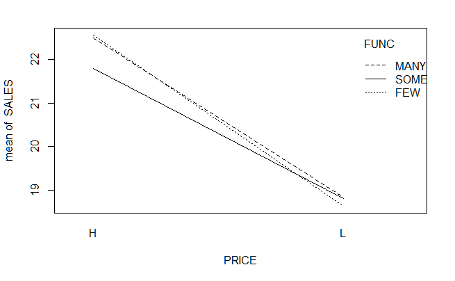

```r
attach(mydata)
interaction.plot(PRICE, FUNC, SALES)
```

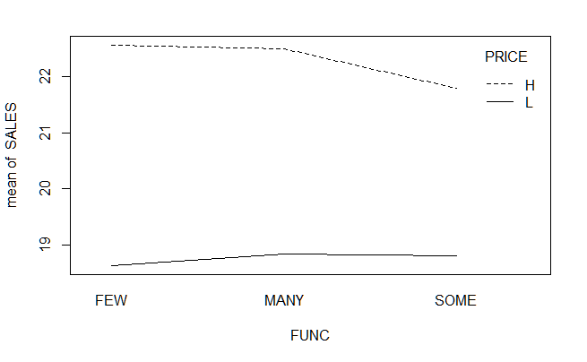

```r
interaction.plot(FUNC, PRICE, SALES)
```

```r
detach(mydata)
```

PRICE variance is bigger than Residuals (variance of entire sample).  
FUNC variance is smaller than Residuals. In the other words, size of sales dispersion become bigger in the next order.  
1. PRICE (high and low)  
2. Residuals  
3. PRICE + FUNC  
4. FUNC (few, some and many)entier sample

### Conclusion

Pricing has impact to sales.  
Interaction effect between pricing and feature has no inpact to sales.

# 2) Evaluate price factor on sales result

## 1 factor ANOVA

```r
emydata2=aov(SALES~PRICE, mydata)
summary(emydata2)
```

```
            Df Sum Sq Mean Sq F value   Pr(>F)
PRICE        1  56.18   56.18   55.72 1.35e-06 ***
Residuals   16  16.13    1.01
---
Signif. codes:  0 ‘***’ 0.001 ‘**’ 0.01 ‘*’ 0.05 ‘.’ 0.1 ‘ ’ 1
```

Mean variacne of PRICE is much bigger than Residuals.  
It shows sales dispersion between PRICE H and L is much different.

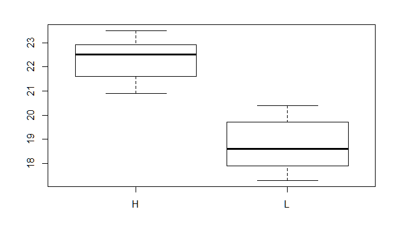

```r
boxplot(SALES~PRICE, mydata)
```

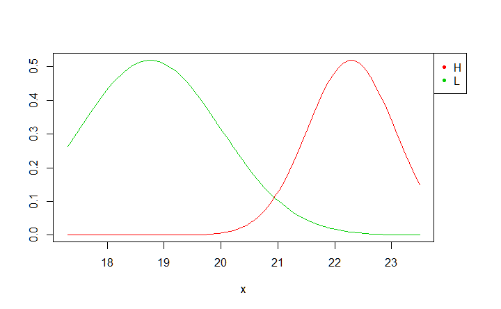

```r
par(mar=c(5,4,4,5))
drawPrice(mydata)
```

# 3) Evaluate feature factor on sales result

## 1 factor ANOVA

```r
emydata3=aov(SALES~FUNC, mydata)
summary(emydata3)
```

```
            Df Sum Sq Mean Sq F value Pr(>F)
FUNC         2   0.46   0.229   0.048  0.953
Residuals   15  71.85   4.790
```

Mean variacne of FUNC is much smaller than Residuals.  
It shows sales dispersion among FUNC has not so big difference.

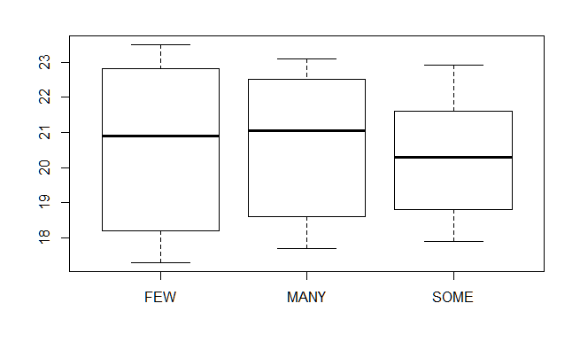

```r
boxplot(SALES~FUNC, mydata)
```

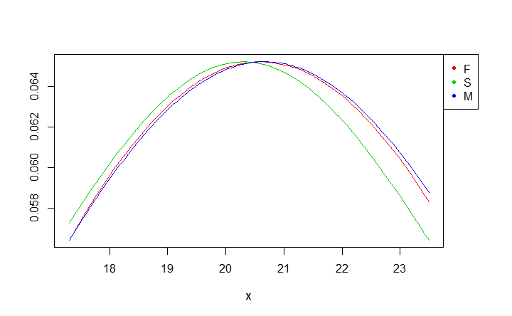

```r
par(mar=c(5,4,4,5))
drawFunc(mydata)
```